# 3_Hashtag_network

Ursula Widocki

11/23/2019

## Twitter’s Reaction to the fifth 2019 Democratic Primary Debate

This markdown file exhibits the pipeline for processing the data and into the network

#### What is a hashtag?

A hastag is a word or phrase detected by the “#” symbol and is used on social media to emphasize specific topics.

The hashtags we used to scrape tweets are #DemDebate, since that was the official hashtag of the event, and two hashtags pertaining to the top four Democratic candidates: #JoeBiden, #JoeBiden2020, #PeteButtigieg, #PeteForPresident, #ElizabethWarren, #Warren2020, #BernieSanders, #Bernie2020.

```r
hashtags <- c("#DemDebate", "#JoeBiden","#JoeBiden2020", "#PeteButtigieg", "#PeteForPresident", "#ElizabethWarren", "#Warren2020", "#BernieSanders", "#Bernie2020")

tweetDF2 <- tweetDF$text
tweetDF2 <- as.data.frame(tweetDF2)
colnames(tweetDF2) <- c("text")
tweetDF2 <- na.omit(tweetDF2)
```

We randomly sampled 10,000 tweets that have hastags to create our network

We extracted all of the hashtags present in the sampled tweets

Next, we cleaned the hashtags. First, any non-ASCII detected hashtags were removed. Although foreign characters were removed, emojis were not and were difficult to detect for removal. Links were not detected as strings and could not be removed.

The hashtags were filtered by observation and removed by the following criteria: emojis, website links, punctuation, another hashtag, twitter handle.

The first 100 hashtags that fit the criterion were selected

We compute the weighted adjacency matrix. Two hashtags are connected if they appear in the same tweet. The diagonal of the matrix was used as a way of calculating the frequency of each hashtag.

### Exploring the network

#### Looking at network metrics

```r
# number of nodes
length(V(hash_net)) # 100
```

```
## [1] 100
```

```r
# number of edges
length(E(hash_net)) # 259
```

```
## [1] 259
```

```r
# density of the graph
edge_density(hash_net, loops=F) # 0.05
```

```
## [1] 0.05232323
```

```r
# which hashtags have the greatest frequency of occurrence
clean_hashtags[which.max(nodeWeight)]
```

```
## [1] "#DemDebate"
```

```r
clean_hashtags[order(nodeWeight, decreasing = T)[1:5]] # prints the top 5
```

```
## [1] "#DemDebate"        "#DemocraticDebate" "#YangGang"
## [4] "#demdebate"        "#Bernie2020"
```

```r
# which hashtags only occured once
# by the way the nodeWeight vector was constructed, if a hashtag did not reoccur, then the value is 0
zeroEdgeInd <- which(nodeWeight <= 1)
length(clean_hashtags[zeroEdgeInd]) # 22
```

```
## [1] 22
```

```r
# what is the largest connected component
diameter(hash_net, directed=F, weights=NA)
```

```
## [1] 4
```

```r
#diameter(hash_net, directed=F) # with weights
get_diameter(hash_net, directed=F)
```

```
## + 3/100 vertices, named, from 1084e28:
## [1] X.DemDebatePresident X.DemDebate          X.CoalMineSteyer
```

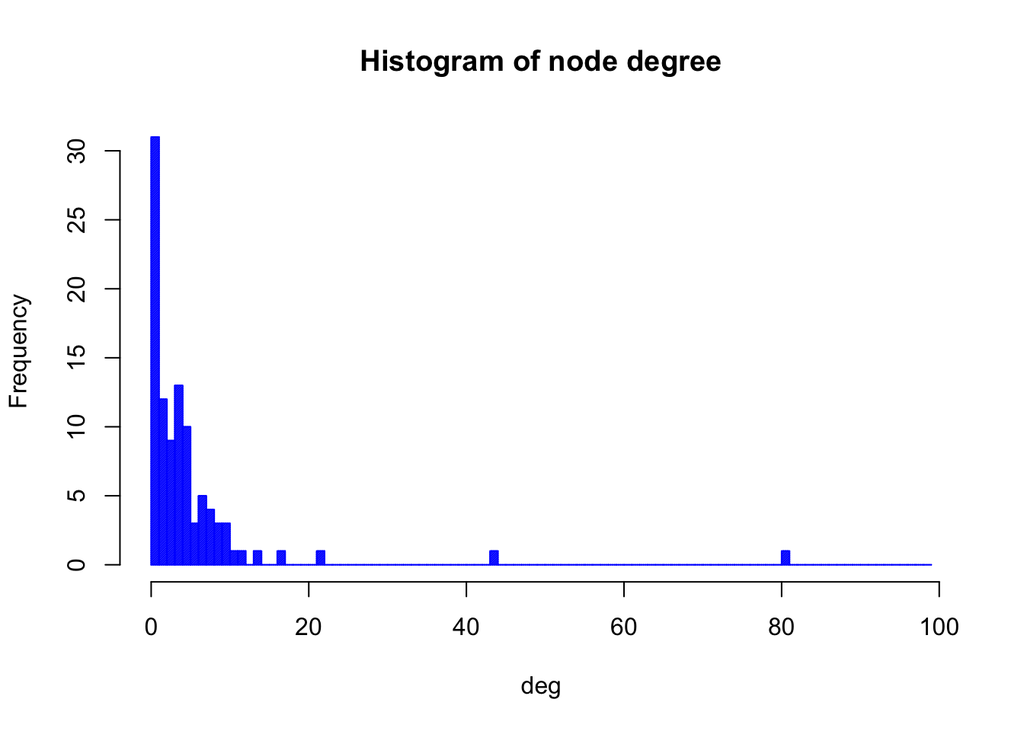

```r
# plot the degree distribution
deg <- degree(hash_net, mode="all")
hist(deg, breaks=1:vcount(hash_net)-1, main="Histogram of node degree", density = 100, col = "blue")
```

```r
# top nodes by degree
clean_hashtags[order(deg, decreasing = T)[1:5]] # prints the top 5
```

```
## [1] "#DemDebate"        "#DemocraticDebate" "#DemDebates"
## [4] "#demdebate"        "#Bernie2020"
```

```r
# number of hashtags with degree 0
length(which(deg == 0))
```

```
## [1] 9
```

#### Interactive network

This interactive network allows the user to zoom in and out of the network to better see connections between nodes. When the user brings their mouse over a node, the subnetwork of hashtags associated with the node are highlighted. The user can also drag node to analyze the network.

```r
interactive_net
```

[interactive chart not shown]

Looking at the hashtags connected to the names of our four target candidates, we observed some interesting relations: Bernie Sanders is linked to hashtags relating to universal healthcare, climate change, the status quo, and #NotMeUs. Elizabeth Warren is mainly connected to #DreamBigFightHard and Kamala Harris. Joe Biden is linked to only hashtags relating to the debate in general. Pete Buttigieg is connected to hashtags mainly relating the the general debate and his candidacy for president with occasional connections to Kamala Harris and Tulsi Gabbard.

It is important to note that there is selection bias regard #DemDebate since it was one of our target hashtags for scraping. How would our network structure change if we were to remove #DemDebate?

```r
interactive_net_rm
```

[interactive chart not shown]

From the above calculations, #DemocraticDebate is the node with the next highest degree. Since this hashtag is prominent due to bias from our main topic, we expected to appear due to the nature of the other hashtags. Two detached subnetworks appear: #courage linked to #integrity and #PaidFamilyLeave linked to #childcare.

Now, what would our network look like if we removed #DemocraticDebate?

```r
interactive_net_rm2
```

[interactive chart not shown]

Overall, these networks suggest that Bernie Sanders and Andrew Yang have a strong Twitter audience compared to other candidates. Although this is not a surprising result about Sanders, it is surprising about Yang given his lesser popularity.